# Regression

## Load packages

```r
library(tidyverse)
library(segmented)
library(readxl)
library(ggpubr)
library(ggrepel)
```

## Load data

```r
# Rt data
ontario <- read_csv('Estimated_R/ontario_R.csv')
peel <- read_csv('Estimated_R/peel_R.csv')
toronto <- read_csv('Estimated_R/tor_R.csv')
waterloo <- read_csv('Estimated_R/wat_R.csv')
york <- read_csv('Estimated_R/york_R.csv')
# Timeline data
o_tl <- read_excel('Mobility&Rt January 30.xlsx',
                   sheet = 'Ontario Timeline')
p_tl <- read_excel('Mobility&Rt January 30.xlsx',
                   sheet = 'Peel Timeline')
t_tl <- read_excel('Mobility&Rt January 30.xlsx',
                   sheet = 'Toronto Timeline')
w_tl <- read_excel('Mobility&Rt January 30.xlsx',
                   sheet = 'Waterloo Timeline')
y_tl <- read_excel('Mobility&Rt January 30.xlsx',
                   sheet = 'York Timeline')
```

## Functions

```r
# create segmented regressions
# input Rt data, plot name, and breakpoints (if available)
# output segments, plot, and breakpoints

segmented_regressions <- function(data, name, breaks=NULL) {

  # filter data to all start on same date
  data <- data %>%
    filter(date_start>='2020-03-12')
  # make linear regression for entire data
  my.lm <- lm(`Mean(R)` ~ date_start, data = data)
  # make segmented regression
  if (is.null(breaks)) {
    my.seg <- segmented(my.lm,
                        seg.Z = ~ date_start)
    breaks <- my.seg$psi[, 2]
  } else {
    my.seg <- segmented(my.lm,
                        seg.Z = ~ date_start,
                        fixed.psi = list(date_start=breaks$Date))
  }

  # get the fitted data
  my.fitted <- fitted(my.seg)
  my.model <- data.frame(date_start = data$date_start,
                         Mean_R = my.fitted)
  # plot the fitted model
  p <- ggplot(data, aes(x = date_start, y = `Mean(R)`)) +
    geom_line() +
    geom_line(my.model,
              mapping=aes(x = date_start, y = Mean_R),
              color='blue') +
    labs(title=name) +
    xlab('Date')

  return(list(my.seg=my.seg, plot=p, breaks=breaks))
}
```

```r
# annotate_plot <- function(plot, breaks, timeline) {
#
#   if (is.numeric(breaks)) {
#     p <- plot +
#       geom_vline(xintercept = breaks,
#                  linetype = "dashed")
#   } else {
#     p <- plot +
#       geom_rect(timeline,
#                 mapping = aes(xmin=break_start, xmax=break_end,
#                               ymin=-Inf, ymax=+Inf,
#                               color=restrictions)) +
#       geom_vline(breaks,
#                  mapping = aes(xintercept=Date),
#                  linetype = "dashed") +
#       geom_label_repel(breaks,
#                        mapping=aes(label=Milestone,x=Date,y=3.5),
#                        size=2)
#   }
#
#   return(p)
# }
```

```r
regression_eqs <- function(data, my.seg, breaks) {
  # get slopes of segments
  slopes <- slope(my.seg)
  # get intercepts of segments
  intercepts <- intercept(my.seg)
  # get first date in data
  first <- first(data$date_start)
  # get last date
  last <- last(data$date_start)
  # get mystery break point and find difference between first date
  x <- my.seg$psi[, 2] - as.numeric(first, 'yyyy-mm-dd')
  # add to first date to get mystery date object
  calc <- first + round(x)
  # create new dates vector
  new_dates <- c(first, last, calc)
  # append to known dates and sort
  if(!is.numeric(breaks)){
    segs <- sort(append(breaks$Date, new_dates))
  } else {
    segs <- sort(new_dates)
  }

  # create data frame of all the info
  df <- data.frame(break_start=segs[1:length(segs)-1],
                   break_end=segs[-1],
                   slope=slopes$date_start[,1],
                   intercept=intercepts$date_start[,1])
  return(df)
}
```

## Ontario

Data starts on 3/4/20 Date Milestone  
3/17/20 Emergency declared 5/14/20 Phase2 :Restart. Guidelines issued  
9/28/20 Enters Stage 2/ Second Wave of Pandemic official announcement  
12/26/20 Grey

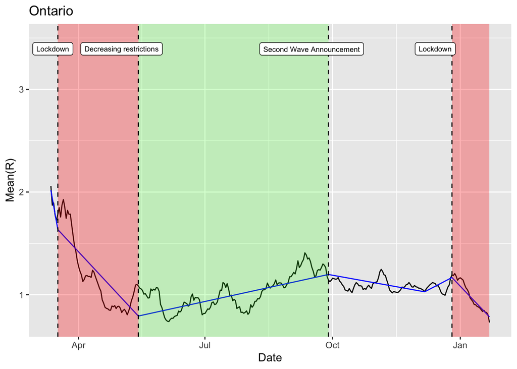

```r
# get list of break points
dates <-  as.Date(c('2020-03-17', '2020-05-14', '2020-09-28', '2020-12-26'))

breaks <- o_tl %>%
  mutate(Date = as.Date(Date)) %>%
  filter(Date %in% dates) %>%
  mutate(Milestone = paste(Date, Milestone, sep='\n'))

res <- segmented_regressions(ontario, 'Ontario', breaks)
df <- regression_eqs(ontario, res$my.seg, res$breaks)

ont_fix_plot <- res$plot +
  annotate('rect', xmin=df$break_start[2], xmax=df$break_end[2],
           ymin=-Inf, ymax=+Inf,
           fill='red', alpha=0.3) +
  annotate('rect', xmin=df$break_start[3], xmax=df$break_end[3],
           ymin=-Inf, ymax=+Inf,
           fill='green', alpha=0.2) +
  annotate('rect', xmin=df$break_start[6], xmax=df$break_end[6],
           ymin=-Inf, ymax=+Inf,
           fill='red', alpha=0.3) +
  geom_vline(breaks,
             mapping = aes(xintercept=Date),
             linetype = "dashed") +
  geom_label_repel(breaks,
                   mapping=aes(label=c("Lockdown", "Decreasing restrictions", "Second Wave Announcement", "Lockdown"),
                               x=Date,y=3.5),
                   size=2.5)

ggsave('Breakpoint_Analysis/Fixed/Ontario/Ontario_Fixed_Breaks.png',
       ont_fix_plot,
       height = 8.5,
       width = 11,
       units = 'in')
write_csv(df, 'Breakpoint_Analysis/Fixed/Ontario/Ontario_Fixed_Breaks.csv')
ont_fix_plot
```

```r
df
```

```
##        break_start  break_end      slope intercept
## slope1  2020-03-04 2020-03-17 -0.0766230  1406.800
## slope2  2020-03-17 2020-05-14 -0.0145180   267.870
## slope3  2020-05-14 2020-09-28  0.0029540   -53.549
## slope4  2020-09-28 2020-12-06 -0.0024333    46.293
## slope5  2020-12-06 2020-12-26  0.0070747  -130.580
## slope6  2020-12-26 2021-01-22 -0.0141880   265.380
```

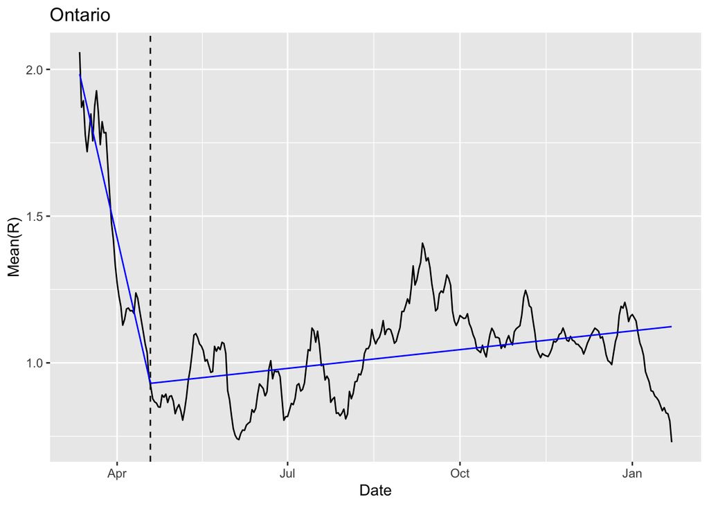

```r
res <- segmented_regressions(ontario, 'Ontario')
df <- regression_eqs(ontario, res$my.seg, res$breaks)
ggsave('Breakpoint_Analysis/Default/Ontario/Ontario_Default_Breaks.png',
       res$plot,
       height = 8.5,
       width = 11,
       units = 'in')
write_csv(df, 'Breakpoint_Analysis/Default/Ontario/Ontario_Default_Breaks.csv')
ont_def_plot <- res$plot +
  geom_vline(xintercept = res$breaks,
             linetype = "dashed")
ont_def_plot
```

```r
df
```

```
##        break_start  break_end       slope intercept
## slope1  2020-03-04 2020-04-19 -0.02791500   513.760
## slope2  2020-04-19 2021-01-22  0.00069483   -11.834
```

## Peel

Data starts on 3/12/20 Date Milestone  
3/17/20 Emergency declared 6/22/20 Enters to Stage 2  
10/11/20 “modified” version of Stage 2 11/9/20 Red 12/14/20 Grey

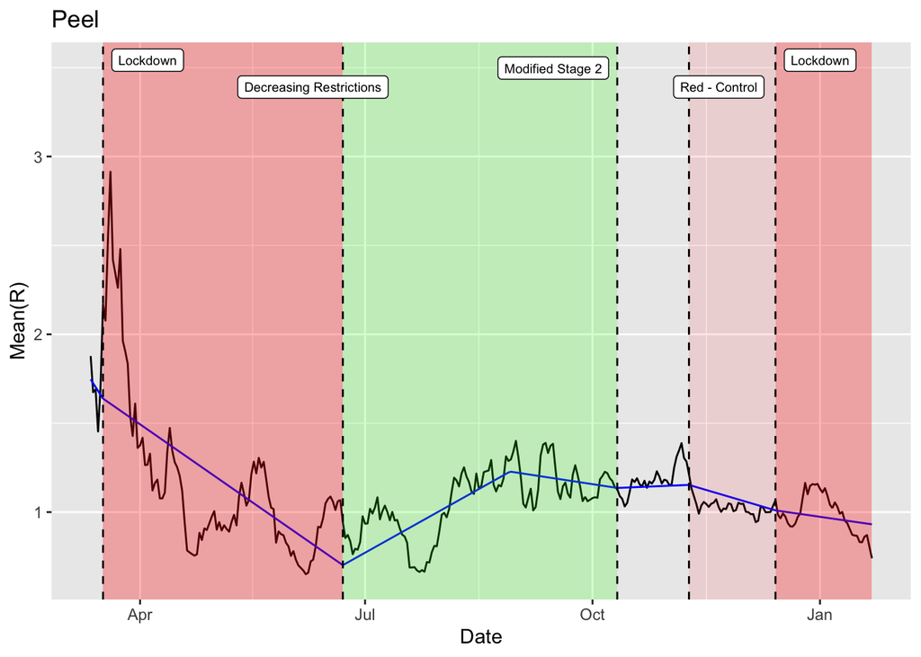

```r
dates <- as.Date(c('2020-03-17', '2020-06-22', '2020-10-11', '2020-11-09', '2020-12-14'))

breaks <- p_tl %>%
  mutate(Date = as.Date(Date)) %>%
  filter(Date %in% dates) %>%
  mutate(Milestone = paste(Date, Milestone, sep='\n'))

res <- segmented_regressions(peel, 'Peel', breaks)
df <- regression_eqs(peel, res$my.seg, res$breaks)

peel_fix_plot <- res$plot +
  annotate('rect', xmin=df$break_start[2], xmax=df$break_end[2],
           ymin=-Inf, ymax=+Inf,
           fill='red', alpha=0.3) +
  annotate('rect', xmin=df$break_start[3], xmax=df$break_end[4],
           ymin=-Inf, ymax=+Inf,
           fill='green', alpha=0.2) +
  annotate('rect', xmin=df$break_start[6], xmax=df$break_end[6],
           ymin=-Inf, ymax=+Inf,
           fill='red', alpha=0.1) +
  annotate('rect', xmin=df$break_start[7], xmax=df$break_end[7],
           ymin=-Inf, ymax=+Inf,
           fill='red', alpha=0.3) +
  geom_vline(breaks,
             mapping = aes(xintercept=Date),
             linetype = "dashed") +
  geom_label_repel(breaks,
                   mapping=aes(label=c('Lockdown', 'Decreasing Restrictions', 'Modified Stage 2', 'Red - Control', 'Lockdown'),x=Date,y=3.5),
                   size=2.5)

ggsave('Breakpoint_Analysis/Fixed/Peel/Peel_Fixed_Breaks.png',
       peel_fix_plot,
       height = 8.5,
       width = 11,
       units = 'in')
write_csv(df, 'Breakpoint_Analysis/Fixed/Peel/Peel_Fixed_Breaks.csv')

peel_fix_plot
```

```r
df
```

```
##        break_start  break_end       slope intercept
## slope1  2020-03-12 2020-03-17 -0.02160300  397.7900
## slope2  2020-03-17 2020-06-22 -0.00965960  178.7800
## slope3  2020-06-22 2020-08-29  0.00778000 -142.7200
## slope4  2020-08-29 2020-10-11 -0.00212230   40.4950
## slope5  2020-10-11 2020-11-09  0.00058811   -9.7712
## slope6  2020-11-09 2020-12-14 -0.00409270   77.1750
## slope7  2020-12-14 2021-01-22 -0.00201120   38.4380
```

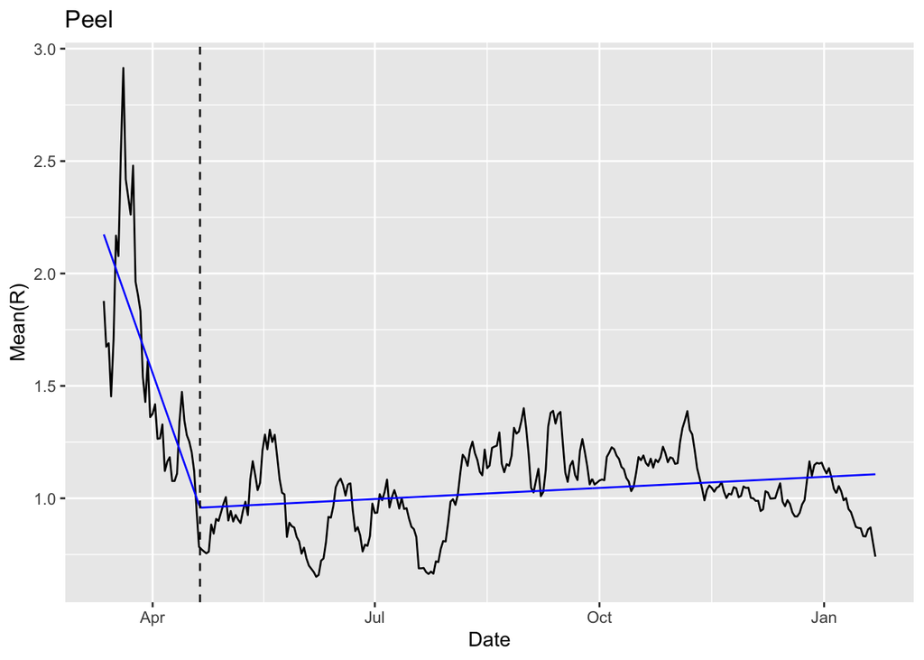

```r
res <- segmented_regressions(peel, 'Peel')
df <- regression_eqs(peel, res$my.seg, res$breaks)
ggsave('Breakpoint_Analysis/Default/Peel/Peel_Default_Breaks.png',
       res$plot,
       height = 8.5,
       width = 11,
       units = 'in')
write_csv(df, 'Breakpoint_Analysis/Default/Peel/Peel_Default_Breaks.csv')
peel_def_plot <- res$plot +
  geom_vline(xintercept = res$breaks,
             linetype = "dashed")

peel_def_plot
```

```r
df
```

```
##        break_start  break_end       slope intercept
## slope1  2020-03-12 2020-04-20 -0.03085400  567.8200
## slope2  2020-04-20 2021-01-22  0.00053706   -8.9089
```

## Toronto

Data starts on 3/4/20 Date Milestone  
3/17/20 State of Emergency declared 6/24/20 enters Stage 2  
11/20/20 Red 12/14/20 Grey

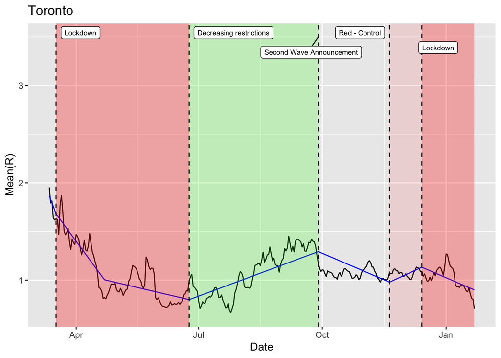

```r
dates <- as.Date(c('2020-03-17', '2020-06-24', '2020-09-28', '2020-11-20','2020-12-14'))

breaks <- t_tl %>%
  mutate(Date = as.Date(Date)) %>%
  filter(Date %in% dates) %>%
  mutate(Milestone = paste(Date, Milestone, sep='\n'))

res <- segmented_regressions(toronto, 'Toronto', breaks)
df <- regression_eqs(toronto, res$my.seg, res$breaks)

tor_fix_plot <- res$plot +
  annotate('rect', xmin=df$break_start[2], xmax=df$break_end[3],
           ymin=-Inf, ymax=+Inf,
           fill='red', alpha=0.3) +
  annotate('rect', xmin=df$break_start[4], xmax=df$break_end[4],
           ymin=-Inf, ymax=+Inf,
           fill='green', alpha=0.2) +
  annotate('rect', xmin=df$break_start[6], xmax=df$break_end[6],
           ymin=-Inf, ymax=+Inf,
           fill='red', alpha=0.1) +
  annotate('rect', xmin=df$break_start[7], xmax=df$break_end[7],
         ymin=-Inf, ymax=+Inf,
         fill='red', alpha=0.3) +
  geom_vline(breaks,
             mapping = aes(xintercept=Date),
             linetype = "dashed") +
  geom_label_repel(breaks,
                   mapping=aes(label=c("Lockdown", "Decreasing restrictions", "Second Wave Announcement", "Red - Control", "Lockdown"),x=Date,y=3.5),
                   size=2.5)

ggsave('Breakpoint_Analysis/Fixed/Toronto/Toronto_Fixed_Breaks.png',
       tor_fix_plot,
       height = 8.5,
       width = 11,
       units = 'in')
write_csv(df, 'Breakpoint_Analysis/Fixed/Toronto/Toronto_Fixed_Breaks.csv')

tor_fix_plot
```

```r
df
```

```
##        break_start  break_end      slope intercept
## slope1  2020-03-04 2020-03-17 -0.0373210   686.070
## slope2  2020-03-17 2020-04-22 -0.0188260   346.910
## slope3  2020-04-22 2020-06-24 -0.0032540    60.793
## slope4  2020-06-24 2020-09-28  0.0051540   -94.226
## slope5  2020-09-28 2020-11-20 -0.0059340   111.270
## slope6  2020-11-20 2020-12-14  0.0063898  -117.780
## slope7  2020-12-14 2021-01-22 -0.0059750   112.330
```

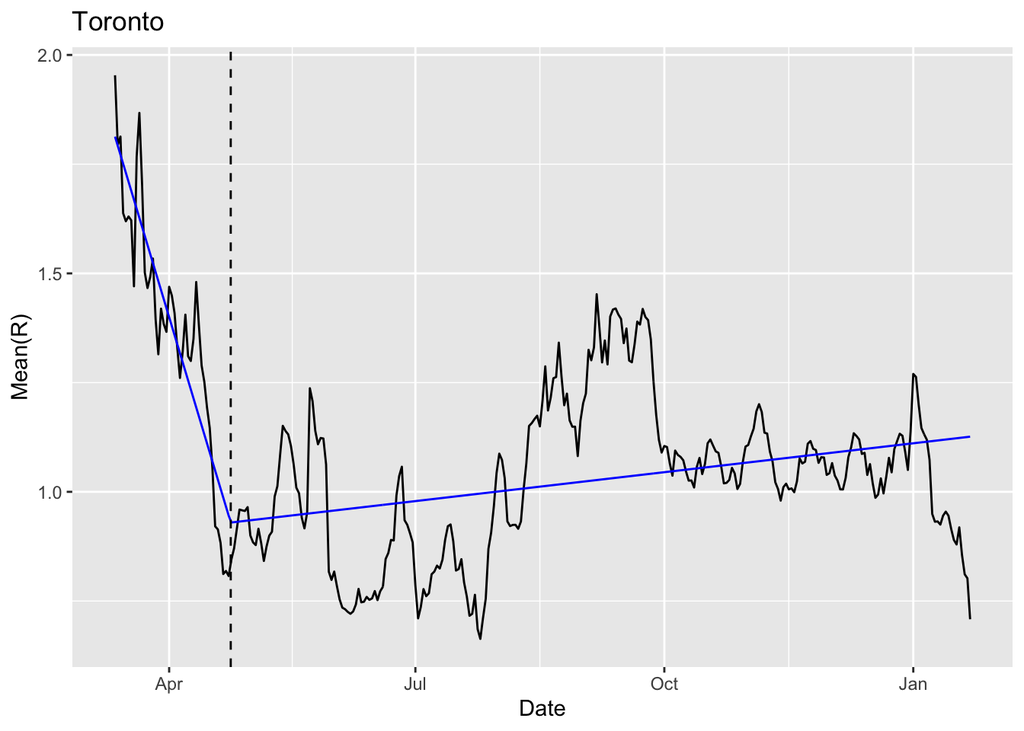

```r
res <- segmented_regressions(toronto, 'Toronto')
df <- regression_eqs(toronto, res$my.seg, res$breaks)
ggsave('Breakpoint_Analysis/Default/Toronto/Toronto_Default_Breaks.png',
       res$plot,
       height = 8.5,
       width = 11,
       units = 'in')
write_csv(df, 'Breakpoint_Analysis/Default/Toronto/Toronto_Default_Breaks.csv')
tor_def_plot <- res$plot +
  geom_vline(xintercept = res$breaks,
             linetype = "dashed")
tor_def_plot
```

```r
df
```

```
##        break_start  break_end       slope intercept
## slope1  2020-03-04 2020-04-24 -0.02065600   380.510
## slope2  2020-04-24 2021-01-22  0.00071932   -12.288
```

## Waterloo

Data starts 3/11/20 Date Milestone  
3/17/20 State of Emergency declared 6/12/20 Move into Stage 2  
9/22/20 Moved to second wave  
11/23/20 Red 12/26/20 Grey

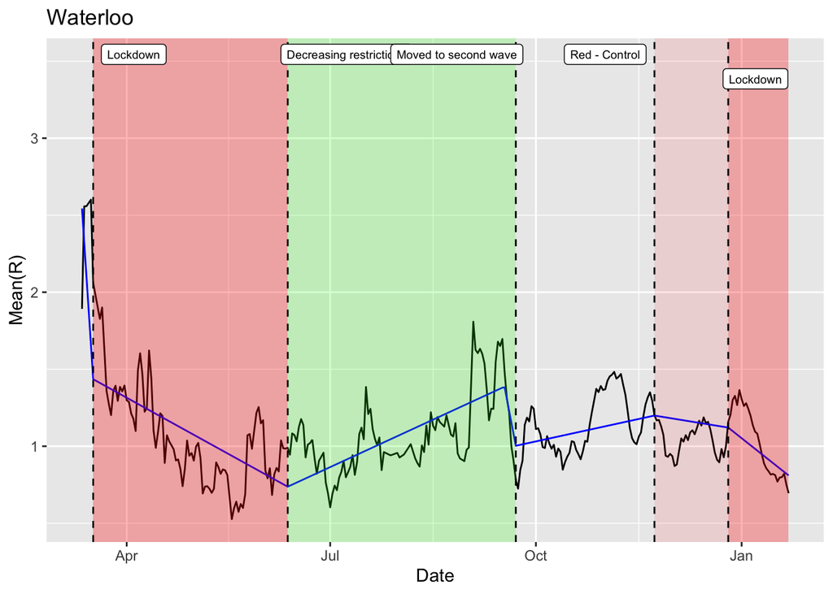

```r
dates <- as.Date(c('2020-03-17', '2020-06-12', '2020-09-22', '2020-11-23', '2020-12-26'))

breaks <- w_tl %>%
  mutate(Date = as.Date(Date)) %>%
  filter(Date %in% dates) %>%
  mutate(Milestone = paste(Date, Milestone, sep='\n'))

res <- segmented_regressions(waterloo, 'Waterloo', breaks)
df <- regression_eqs(waterloo, res$my.seg, res$breaks)

wat_fix_plot <- res$plot +
  annotate('rect', xmin=df$break_start[2], xmax=df$break_end[2],
           ymin=-Inf, ymax=+Inf,
           fill='red', alpha=0.3) +
  annotate('rect', xmin=df$break_start[3], xmax=df$break_end[4],
           ymin=-Inf, ymax=+Inf,
           fill='green', alpha=0.2) +
  annotate('rect', xmin=df$break_start[6], xmax=df$break_end[6],
           ymin=-Inf, ymax=+Inf,
           fill='red', alpha=0.1) +
  annotate('rect', xmin=df$break_start[7], xmax=df$break_end[7],
         ymin=-Inf, ymax=+Inf,
         fill='red', alpha=0.3) +
  geom_vline(breaks,
             mapping = aes(xintercept=Date),
             linetype = "dashed") +
  geom_label_repel(breaks,
                   mapping=aes(label=c("Lockdown", "Decreasing restrictions", "Moved to second wave", "Red - Control", "Lockdown"),x=Date,y=3.5),
                   size=2.5)


ggsave('Breakpoint_Analysis/Fixed/Waterloo/Waterloo_Fixed_Breaks.png',
       wat_fix_plot,
       height = 8.5,
       width = 11,
       units = 'in')
write_csv(df, 'Breakpoint_Analysis/Fixed/Waterloo/Waterloo_Fixed_Breaks.csv')

wat_fix_plot
```

```r
df
```

```
##        break_start  break_end      slope intercept
## slope1  2020-03-11 2020-03-17 -0.2217100  4067.200
## slope2  2020-03-17 2020-06-12 -0.0080221   148.540
## slope3  2020-06-12 2020-09-17  0.0066975  -122.660
## slope4  2020-09-17 2020-09-22 -0.0759180  1407.500
## slope5  2020-09-22 2020-11-23  0.0031647   -57.630
## slope6  2020-11-23 2020-12-26 -0.0023645    45.153
## slope7  2020-12-26 2021-01-22 -0.0115110   215.490
```

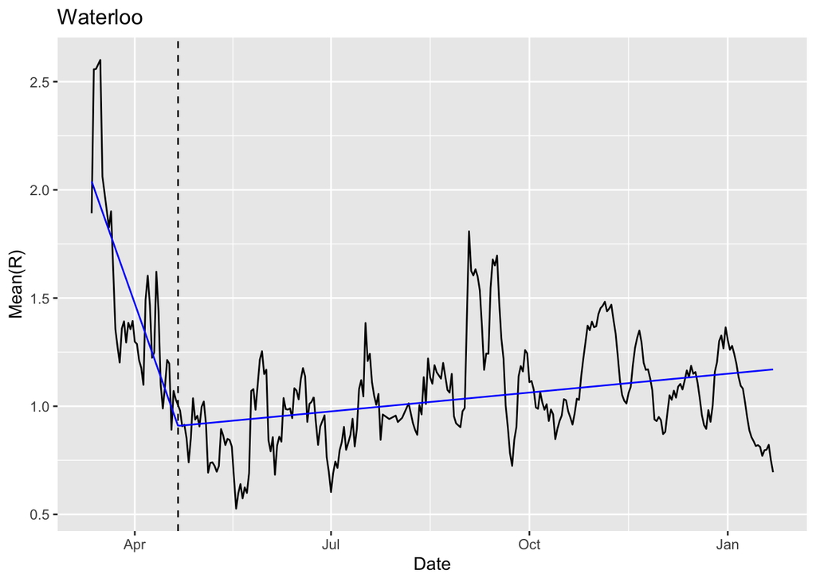

```r
res <- segmented_regressions(waterloo, 'Waterloo')
df <- regression_eqs(waterloo, res$my.seg, res$breaks)
ggsave('Breakpoint_Analysis/Default/Waterloo/Waterloo_Default_Breaks.png',
       res$plot,
       height = 8.5,
       width = 11,
       units = 'in')
write_csv(df, 'Breakpoint_Analysis/Default/Waterloo/Waterloo_Default_Breaks.csv')
wat_def_plot <- res$plot +
  geom_vline(xintercept = res$breaks,
             linetype = "dashed")
wat_def_plot
```

```r
df
```

```
##        break_start  break_end       slope intercept
## slope1  2020-03-11 2020-04-21 -0.02819600   518.960
## slope2  2020-04-21 2021-01-22  0.00094601   -16.472
```

## York

Data starts on 3/10/20 Date Milestone  
3/17/20 State of Emergency Declared  
5/19/20 Phase2 Stage1 reopening  
10/19/20 Modified Stage 2  
11/16/20 Red Level 12/14/20 Grey Level

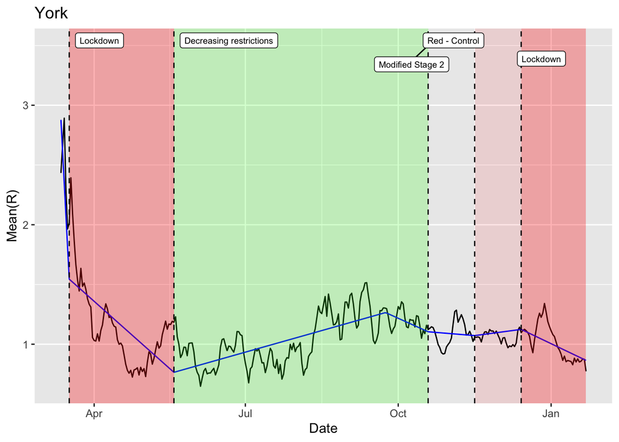

```r
dates <- as.Date(c('2020-03-17', '2020-05-19', '2020-10-19', '2020-11-16','2020-12-14'))

breaks <- y_tl %>%
  mutate(Date = as.Date(Date)) %>%
  filter(Date %in% dates) %>%
  mutate(Milestone = paste(Date, Milestone, sep='\n'))

res <- segmented_regressions(york, 'York', breaks)
df <- regression_eqs(york, res$my.seg, res$breaks)

york_fix_plot <- res$plot +
  annotate('rect', xmin=df$break_start[2], xmax=df$break_end[2],
           ymin=-Inf, ymax=+Inf,
           fill='red', alpha=0.3) +
  annotate('rect', xmin=df$break_start[3], xmax=df$break_end[4],
           ymin=-Inf, ymax=+Inf,
           fill='green', alpha=0.2) +
  annotate('rect', xmin=df$break_start[6], xmax=df$break_end[6],
         ymin=-Inf, ymax=+Inf,
         fill='red', alpha=0.1) +
  annotate('rect', xmin=df$break_start[7], xmax=df$break_end[7],
         ymin=-Inf, ymax=+Inf,
         fill='red', alpha=0.3) +
  geom_vline(breaks,
             mapping = aes(xintercept=Date),
             linetype = "dashed") +
  geom_label_repel(breaks,
                   mapping=aes(label=c("Lockdown", "Decreasing restrictions", "Modified Stage 2", "Red - Control", "Lockdown"),x=Date,y=3.5),
                   size=2.5)

ggsave('Breakpoint_Analysis/Fixed/York/York_Fixed_Breaks.png',
       york_fix_plot,
       height = 8.5,
       width = 11,
       units = 'in')
write_csv(df, 'Breakpoint_Analysis/Fixed/York/York_Fixed_Breaks.csv')

york_fix_plot
```

```r
df
```

```
##        break_start  break_end      slope intercept
## slope1  2020-03-10 2020-03-17 -0.2666100  4890.600
## slope2  2020-03-17 2020-05-19 -0.0123780   228.530
## slope3  2020-05-19 2020-09-23  0.0039273   -71.502
## slope4  2020-09-23 2020-10-19 -0.0062704   117.440
## slope5  2020-10-19 2020-11-16 -0.0011475    22.394
## slope6  2020-11-16 2020-12-14  0.0018596   -33.483
## slope7  2020-12-14 2021-01-22 -0.0066456   124.800
```

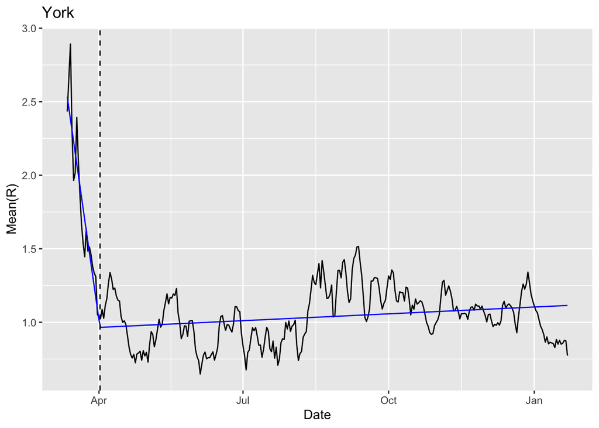

```r
res <- segmented_regressions(york, 'York')
df <- regression_eqs(york, res$my.seg, res$breaks)
ggsave('Breakpoint_Analysis/Default/York/York_Default_Breaks.png',
       res$plot,
       height = 8.5,
       width = 11,
       units = 'in')
write_csv(df, 'Breakpoint_Analysis/Default/York/York_Default_Breaks.csv')
york_def_plot <- res$plot +
  geom_vline(xintercept = res$breaks,
             linetype = "dashed")
york_def_plot
```

```r
df
```

```
##        break_start  break_end      slope intercept
## slope1  2020-03-10 2020-04-02 -0.0756860 1390.1000
## slope2  2020-04-02 2021-01-22  0.0005047   -8.2977
```

Create combined figure

```r
fixed <- ggarrange(ont_fix_plot, peel_fix_plot, tor_fix_plot, wat_fix_plot, york_fix_plot,
          ncol=1)
default <- ggarrange(ont_def_plot, peel_def_plot, tor_def_plot, wat_def_plot, york_def_plot,
          ncol=1)
ggsave('Breakpoint_Analysis/Fixed/Fixed.png',
       fixed,
       height = 11,
       width = 8.5,
       units = 'in')
ggsave('Breakpoint_Analysis/Default/Default.png',
       default,
       height = 11,
       width = 8.5,
       units = 'in')
```